# **第五章: 非约束性排序 – Unconstrained Ordination**

#### 5.4.2.2 使用对应分析双序图预测 Sulementar 位点或物种

将新增加的位点(对象, 行方向)信息和物种(变量, 列方向)信息投影到对应分析的双序图中, 即新增信息(对象或者变量在坐标系中的位置), 分析与原始数据的点(位点或者物种)之间的关系.

使用分析包 stats 中的 predict() 函数.

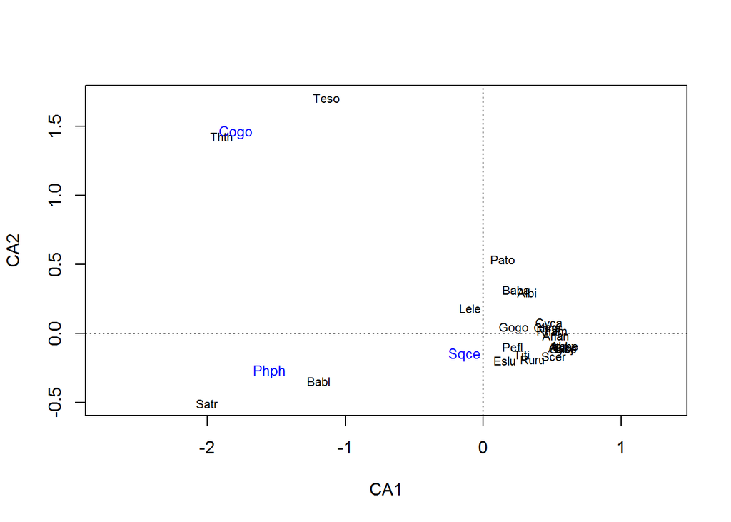

```r
# 预测对应分析中的补充物种
spe.small <- spe[, -c(1, 3, 10)]  # 物种数据集进行删减
spesmall.ca <- cca(spe.small)
plot(spesmall.ca,
     display = "species",
     scaling = 2)
# 对 3 个不同的物种进行分析
newspe3 <- spe[, c(1, 3, 10)]
# 模型预测
ca.newspe <- predict(
                 spesmall.ca,
                 newspe3,
                 type = "sp",
                 scaling = 2)
text(
  ca.newspe[, 1],
  ca.newspe[, 2],
  labels = rownames(ca.newspe),
  cex = 0.8,
  col = "blue"
  )
```

#### 5.4.2.3 环境变量的事后曲线拟合

在 5.3.3.2 中使用 envfit() 函数将环境变量投影到了 PCA 双序图中; 但是, 线性拟合和箭头的投影只能解释**线性的物种-环境关系**. 有时, 会研究 **特定的环境变量** 在非线性的基础上如何与排序结果相关联. 可以通过在排序图上拟合这些环境变量的表面来实现.

使用 envfit() 函数作为第一步处理, 模型的拟合限制在两个变量之间; 使用分析包 vegan 中的 ordisurf() 函数进行曲线拟合, 通过广义加法模型(generalized additive models, GAM)拟合平滑的二维曲线.

```r
# 在对应分析的双序图中进行曲线拟合(Curve fitting)
plot(spe.ca,
     main = "CA fish abundances - scaling 2",
     sub = "Fitted curves: discharge (red), ammonium (green)")
# envfit() https://www.rdocumentation.org/packages/vegan/versions/2.4-2/topics/envfit
# 将环境变量或因子拟合到排序结果上
# envfit() 寻找 环境变量中的向量或者因子平均值
# ? 点向量的投影与相应的环境变量具有最大的相关性, 这些因子表示因子水平的平均值
# envfit() 对 环境变量 进行 置换检验, 计算 变量的 p-value
spe.ca.env <- envfit(spe.ca ~ dis + amm, # 保留两个变量
                     env) # 注意这种表示!!!
plot(spe.ca.env)
# 在排序结果上绘制拟合曲线
# ordisurf https://www.rdocumentation.org/packages/vegan/versions/2.4-2/topics/ordisurf
ordisurf(spe.ca,
         env$dis,
         add = TRUE) # 添加轮廓 | 重新绘制 - False
```

```
##
## Family: gaussian
## Link function: identity
##
## Formula:
## y ~ s(x1, x2, k = 10, bs = "tp", fx = FALSE)
##
## Estimated degrees of freedom:
## 4.29  total = 5.29
##
## REML score: 123.1156
```

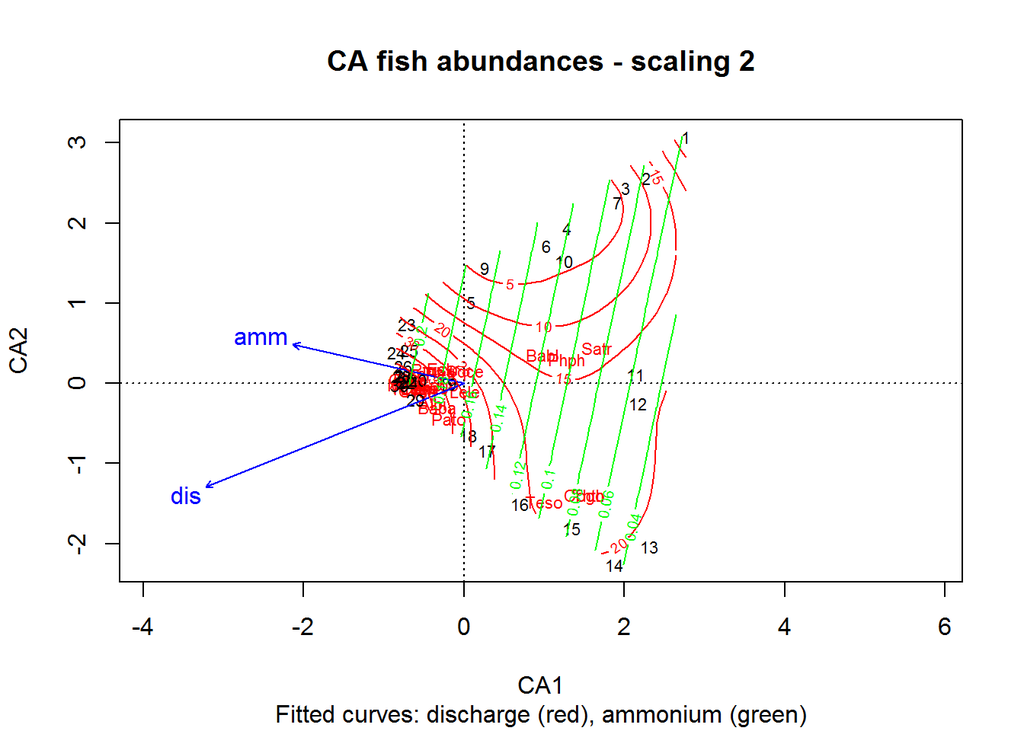

```
##
## Family: gaussian
## Link function: identity
##
## Formula:
## y ~ s(x1, x2, k = 10, bs = "tp", fx = FALSE)
##
## Estimated degrees of freedom:
## 1.16  total = 2.16
##
## REML score: 2.949274
```

```r
ordisurf(spe.ca,
         env$amm,
         add = TRUE,
         col = "green")
```

#### 5.4.2.4 在排序结果轴的基础上重新对数据表进行排序

对应分析的结果有时会根据第一排序轴对数据表进行重新排序. 可以使用分析包 vegan 中的 vegemite() 函数比较重新排序表和原始表. 还可以通过 tabasco() 函数将有序丰度表通过热图的形式进行展示.

```r
# 对应分析之后的物种数据表
# vegemite() 展示紧凑的群落表
# https://www.rdocumentation.org/packages/vegan/versions/2.4-2/topics/vegemite
vegemite(spe, spe.ca)
```

```
##
##       2322222222211  11 1 11  11 1
##       40867235190985976604547312231
##  Icme .53122..14...................
##  Blbj 155244..3421.................
##  Abbr .53234..3411.................
##  Gyce 255454.135211................
##  Anan .54232..24211..1.............
##  Alal 5555552355532..2.............
##  Scer .52112.12221.2...............
##  Rham .54233..35322..1.............
##  Legi 134233..25211..11............
##  Cyca .54123..23111..11............
##  Chna 111113..22221..1.............
##  Ruru 255455115555254211...........
##  Albi .51111..23323..41............
##  Titi .54354..4342131112.11........
##  Baba .33245..45423..32...21.......
##  Gogo 154345.2554422.1211121.......
##  Pefl .52114..342134.211.2.........
##  Eslu .43243.1352114.111.2.1.1.....
##  Pato .21.12..22233..44............
##  Sqce 23423411243132522221311.11...
##  Lele .32123.1232225.3512.3.1......
##  Babl ..1111..11253234554554551432.
##  Teso .........1.11..25...43.....2.
##  Phph ........11133314344545454445.
##  Cogo ............1..12...33..12.2.
##  Thth .........1..1..1....24..12.3.
##  Satr .........1..12.23314455535553
##   sites species
##      29      27
```

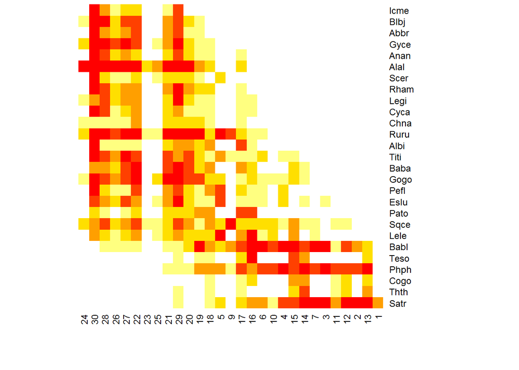

```r
# 通过热图来展示对应分析排序的物种表
# 展示紧凑的群落表 - 热图形式
tabasco(spe, spe.ca)
```

### 5.4.3 使用 CA.newr() 进行对应分析(CA)

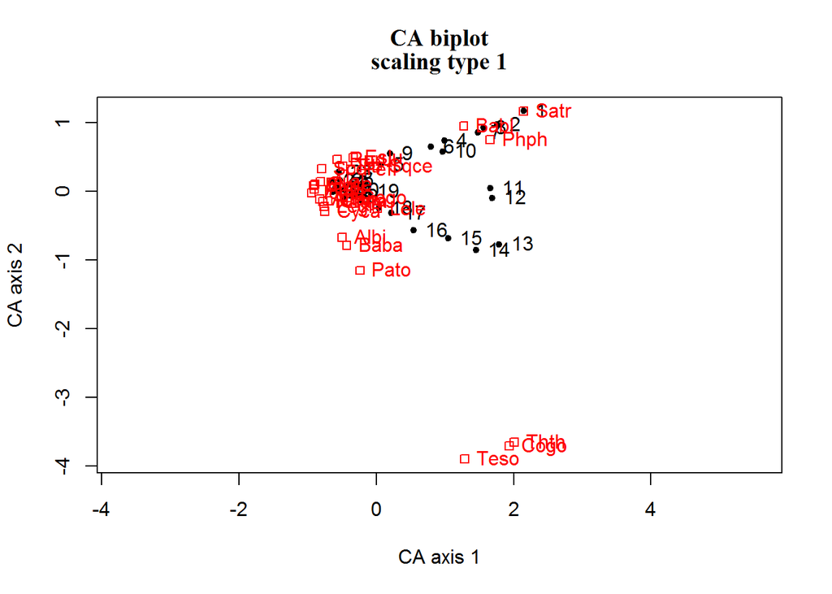

```r
# 使用 CA.newr() 进行对应分析(CA)
spe.CA.PL <- CA.newr(spe)

# par(mfrow = c(1, 2))
biplot.CA(spe.CA.PL,
          scaling = 1, # scaling 1 -- distance biplot
          cex = 1)
```

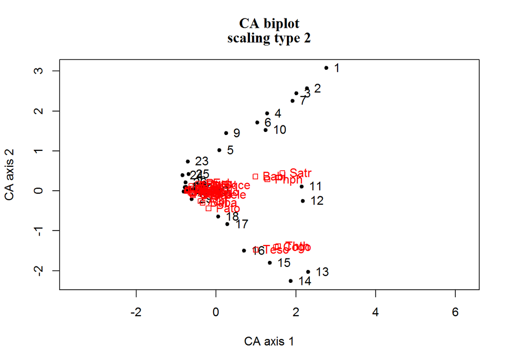

```r
biplot.CA(spe.CA.PL,
          scaling = 2, # scaling 2 -- correlation biplot
          cex = 1)
```

```r
# 按照对应分析结果的第一轴对数据表进行排序分析
summary(spe.CA.PL)
```

```
##          Length Class  Mode
## general  4      -none- list
## scaling1 2      -none- list
## scaling2 2      -none- list
## scaling3 2      -none- list
## scaling4 2      -none- list
## fit      2      -none- list
## other    8      -none- list
```

```r
# 数据结果转置
t(spe[order(as.vector(spe.CA.PL$scaling1$sites[, 1])),
      order(as.vector(spe.CA.PL$scaling1$species[, 1]))])
```

```
##      24 30 28 26 27 22 23 25 21 29 20 19 18 5 9 17 16 6 10 4 15 14 7 3 11
## Icme  0  5  3  1  2  2  0  0  1  4  0  0  0 0 0  0  0 0  0 0  0  0 0 0  0
## Blbj  1  5  5  2  4  4  0  0  3  4  2  1  0 0 0  0  0 0  0 0  0  0 0 0  0
## Abbr  0  5  3  2  3  4  0  0  3  4  1  1  0 0 0  0  0 0  0 0  0  0 0 0  0
## Gyce  2  5  5  4  5  4  0  1  3  5  2  1  1 0 0  0  0 0  0 0  0  0 0 0  0
## Anan  0  5  4  2  3  2  0  0  2  4  2  1  1 0 0  1  0 0  0 0  0  0 0 0  0
## Alal  5  5  5  5  5  5  2  3  5  5  5  3  2 0 0  2  0 0  0 0  0  0 0 0  0
## Scer  0  5  2  1  1  2  0  1  2  2  2  1  0 2 0  0  0 0  0 0  0  0 0 0  0
## Rham  0  5  4  2  3  3  0  0  3  5  3  2  2 0 0  1  0 0  0 0  0  0 0 0  0
## Legi  1  3  4  2  3  3  0  0  2  5  2  1  1 0 0  1  1 0  0 0  0  0 0 0  0
## Cyca  0  5  4  1  2  3  0  0  2  3  1  1  1 0 0  1  1 0  0 0  0  0 0 0  0
## Chna  1  1  1  1  1  3  0  0  2  2  2  2  1 0 0  1  0 0  0 0  0  0 0 0  0
## Ruru  2  5  5  4  5  5  1  1  5  5  5  5  2 5 4  2  1 1  0 0  0  0 0 0  0
## Albi  0  5  1  1  1  1  0  0  2  3  3  2  3 0 0  4  1 0  0 0  0  0 0 0  0
## Titi  0  5  4  3  5  4  0  0  4  3  4  2  1 3 1  1  1 2  0 1  1  0 0 0  0
## Baba  0  3  3  2  4  5  0  0  4  5  4  2  3 0 0  3  2 0  0 0  2  1 0 0  0
## Gogo  1  5  4  3  4  5  0  2  5  5  4  4  2 2 0  1  2 1  1 1  2  1 0 0  0
## Pefl  0  5  2  1  1  4  0  0  3  4  2  1  3 4 0  2  1 1  0 2  0  0 0 0  0
## Eslu  0  4  3  2  4  3  0  1  3  5  2  1  1 4 0  1  1 1  0 2  0  1 0 1  0
## Pato  0  2  1  0  1  2  0  0  2  2  2  3  3 0 0  4  4 0  0 0  0  0 0 0  0
## Sqce  2  3  4  2  3  4  1  1  2  4  3  1  3 2 5  2  2 2  2 1  3  1 1 0  1
## Lele  0  3  2  1  2  3  0  1  2  3  2  2  2 5 0  3  5 1  2 0  3  0 1 0  0
## Babl  0  0  1  1  1  1  0  0  1  1  2  5  3 2 3  4  5 5  4 5  5  4 5 5  1
## Teso  0  0  0  0  0  0  0  0  0  1  0  1  1 0 0  2  5 0  0 0  4  3 0 0  0
## Phph  0  0  0  0  0  0  0  0  1  1  1  3  3 3 1  4  3 4  4 5  4  5 4 5  4
## Cogo  0  0  0  0  0  0  0  0  0  0  0  0  1 0 0  1  2 0  0 0  3  3 0 0  1
## Thth  0  0  0  0  0  0  0  0  0  1  0  0  1 0 0  1  0 0  0 0  2  4 0 0  1
## Satr  0  0  0  0  0  0  0  0  0  1  0  0  1 2 0  2  3 3  1 4  4  5 5 5  3
##      12 2 13 1
## Icme  0 0  0 0
## Blbj  0 0  0 0
## Abbr  0 0  0 0
## Gyce  0 0  0 0
## Anan  0 0  0 0
## Alal  0 0  0 0
## Scer  0 0  0 0
## Rham  0 0  0 0
## Legi  0 0  0 0
## Cyca  0 0  0 0
## Chna  0 0  0 0
## Ruru  0 0  0 0
## Albi  0 0  0 0
## Titi  0 0  0 0
## Baba  0 0  0 0
## Gogo  0 0  0 0
## Pefl  0 0  0 0
## Eslu  0 0  0 0
## Pato  0 0  0 0
## Sqce  1 0  0 0
## Lele  0 0  0 0
## Babl  4 3  2 0
## Teso  0 0  2 0
## Phph  4 4  5 0
## Cogo  2 0  2 0
## Thth  2 0  3 0
## Satr  5 5  5 3
```

```r
# 物种的累积拟合 - Cumulative fit of species
spe.CA.PL$fit$cumulfit.spe
```

```
##        Cum.axis.1 Cum.axis.2 Cum.axis.3 Cum.axis.4 Cum.axis.5 Cum.axis.6
## Cogo 0.4852111314 0.91369174  0.9283097  0.9486409  0.9645534  0.9645560
## Satr 0.7700386702 0.82504861  0.9174829  0.9251746  0.9442992  0.9740452
## Phph 0.8645355090 0.90713065  0.9083199  0.9084918  0.9094977  0.9305794
## Babl 0.7093583266 0.80427418  0.8949011  0.8949604  0.8950694  0.9418726
## Thth 0.4128767029 0.74243443  0.8530209  0.8904684  0.9283697  0.9370394
## Teso 0.2499461547 0.80055649  0.8585650  0.8601498  0.8629595  0.8907449
## Chna 0.3908137714 0.39425543  0.3944188  0.4063628  0.5962219  0.6197724
## Pato 0.0282831261 0.18698307  0.4602634  0.6093653  0.8949285  0.9019191
## Lele 0.0002581779 0.01339547  0.4940897  0.5590549  0.5822435  0.8010541
## Sqce 0.0001768957 0.03025050  0.2146660  0.6555795  0.7078243  0.7503097
## Baba 0.3031826522 0.54944056  0.5560582  0.6356688  0.7029820  0.7319169
## Albi 0.1667460369 0.24062107  0.2865717  0.4451483  0.6138957  0.6786344
## Gogo 0.4321901166 0.43713239  0.4601694  0.4642488  0.4651178  0.5673220
## Eslu 0.1600368859 0.24202651  0.2421155  0.3210596  0.5246837  0.6861360
## Pefl 0.1402059150 0.16477842  0.2248077  0.4514562  0.5312234  0.5761527
## Rham 0.6754633839 0.68157772  0.7584414  0.8437591  0.8485870  0.9320258
## Legi 0.6610243934 0.67408525  0.7603823  0.7652171  0.7930823  0.8157838
## Scer 0.4137011810 0.43054575  0.4498107  0.4732669  0.5825700  0.7080077
## Cyca 0.5533452159 0.57354875  0.6405999  0.7974628  0.7975402  0.8362244
## Titi 0.3958226669 0.44837491  0.4652651  0.4905787  0.6717691  0.6741284
## Abbr 0.5900112514 0.59016009  0.7838539  0.8373985  0.8602381  0.8811725
## Icme 0.4033856880 0.40344794  0.6365890  0.7144935  0.7742204  0.7965394
## Gyce 0.6290589224 0.63104823  0.8171032  0.8614333  0.8649677  0.8651298
## Ruru 0.3466502716 0.40223512  0.5019156  0.7134231  0.7432871  0.7466945
## Blbj 0.6516039110 0.65295666  0.8698766  0.8710598  0.8741761  0.8911750
## Alal 0.3454838808 0.34797510  0.3680242  0.7474121  0.8966397  0.9336640
## Anan 0.6339853939 0.63673825  0.7787744  0.8575038  0.8589575  0.9236933
##      Cum.axis.7 Cum.axis.8 Cum.axis.9 Cum.axis.10 Cum.axis.11 Cum.axis.12
## Cogo  0.9648462  0.9651326  0.9653126   0.9668219   0.9718887   0.9727989
## Satr  0.9776183  0.9994485  0.9995408   0.9996504   0.9998103   0.9999200
## Phph  0.9486189  0.9777822  0.9807687   0.9815243   0.9817738   0.9913580
## Babl  0.9538410  0.9707942  0.9736485   0.9749379   0.9810243   0.9875961
## Thth  0.9874630  0.9882893  0.9884950   0.9886207   0.9886213   0.9886248
## Teso  0.9587172  0.9605874  0.9617362   0.9659895   0.9877910   0.9883682
## Chna  0.6767938  0.6777144  0.8154528   0.8184838   0.8688131   0.8953060
## Pato  0.9131886  0.9355328  0.9365529   0.9370354   0.9381018   0.9535929
## Lele  0.8175087  0.8385962  0.8764588   0.8869294   0.9548638   0.9627910
## Sqce  0.8048654  0.9180156  0.9506997   0.9565603   0.9767064   0.9860054
## Baba  0.7340666  0.7386499  0.8354066   0.8354158   0.8884601   0.9218791
```

[output cut: 85 more lines]

```
## Gogo   0.9992326   0.9993250   0.9999900           1
## Eslu   0.9993832   0.9994276   0.9999944           1
## Pefl   0.9998058   0.9998342   0.9999865           1
## Rham   0.9974981   0.9988497   0.9999291           1
## Legi   0.9981729   0.9993095   0.9998692           1
## Scer   0.9999714   0.9999798   0.9999802           1
## Cyca   0.9979260   0.9996312   0.9997649           1
## Titi   0.9999579   0.9999581   0.9999976           1
## Abbr   0.9996982   0.9999740   0.9999914           1
## Icme   0.9994303   0.9999199   0.9999868           1
## Gyce   0.9998793   0.9999796   0.9999988           1
## Ruru   0.9998852   0.9998852   0.9999965           1
## Blbj   0.9987125   0.9998898   1.0000000           1
## Alal   0.9999992   0.9999993   1.0000000           1
## Anan   0.9979385   0.9992141   0.9992155           1
```

```r
# 位点的累积拟合 - Cumulative fit of sites
spe.CA.PL$fit$cumulfit.obj
```

```
##     Cum.axis.1 Cum.axis.2 Cum.axis.3 Cum.axis.4 Cum.axis.5 Cum.axis.6
## 1  0.276531946 0.35876823  0.5447029  0.5646140  0.6446396  0.7980555
## 2  0.682656282 0.89112936  0.9288517  0.9428682  0.9833486  0.9835256
## 3  0.679405241 0.91819383  0.9260735  0.9406745  0.9560805  0.9597246
## 4  0.530844735 0.82026646  0.8238817  0.8499676  0.8582406  0.8584912
## 5  0.003724619 0.12080405  0.2996742  0.3145835  0.6088135  0.8905337
## 6  0.495890340 0.82385830  0.8995944  0.8996106  0.9333907  0.9385420
## 7  0.699750336 0.93326006  0.9332601  0.9374656  0.9562346  0.9576070
## 9  0.011547482 0.09974598  0.3089200  0.5940195  0.6787402  0.7693997
## 10 0.395939830 0.53886661  0.7146462  0.7206684  0.7312995  0.7723051
## 11 0.761628214 0.76211180  0.8387966  0.8542462  0.8583762  0.8701694
## 12 0.817435313 0.82006597  0.8975788  0.9135066  0.9176164  0.9310181
## 13 0.730069403 0.86616721  0.9560797  0.9630259  0.9679033  0.9681133
## 14 0.665635348 0.89934995  0.9409072  0.9581380  0.9777109  0.9778721
## 15 0.579276604 0.82956670  0.8532310  0.8655875  0.8817882  0.8918225
```

[output cut: 135 more lines]

### 5.4.4 弓形效应与去趋势对应分析 – Arch Effect and Detrended Correspondence Analysis (DCA)

长期的环境梯度通常支持一系列物种. 由于受环境因素控制的物种往往具有**单峰分布**, 因此 长梯度 可能包含在梯度的两端没有共同物种的位点;  
因此, 它们的不相似性具有最大可能值(或它们的相似性为0). 但是如果从梯度的任何一个点开始并慢慢走向终点, 那么连续的站点会比起始点越来越不同, 直到达到D的最大值. 因此, 梯度表示为一对CA轴上的弓形, 而不是直线. 下文将介绍几种**去趋势技术**来解决这种效应, 并使整理图中的梯度变直;

- https://link.springer.com/article/10.1007/BF00048870
- https://en.wikipedia.org/wiki/Detrended_correspondence_analysis
- ** https://mb3is.megx.net/gustame/indirect-gradient-analysis/detrended-correspondence-analysis **
- https://www.pisces-conservation.com/caphelp/index.html?decorana.html
- http://ecology.msu.montana.edu/labdsv/R/labs/lab10/lab10.html
- https://cran.r-project.org/web/packages/vegan/vignettes/intro-vegan.pdf
- http://cc.oulu.fi/~jarioksa/softhelp/vegan/html/decorana.html

去趋势对应分析(DCA):

- **通过与非线性重新缩放相结合的段去趋势:** 轴-1 被分成任意数量的段, 并且在每个段内, 沿 轴-2 的对象得分的平均值等于零. *任意选择的段数对结果有很大影响*. 文献中提出的 DCA 结果表明沿 *第二轴* 的分数基本上意味着更少. 强烈反对使用这种形式的 DCA 作为排序分析技术: 然而, 它可以用于估计 *第一排序轴* 的“辐射长度”, 以物种周转的标准偏差单位表示. **梯度长度大于 4** 表示某些物种沿轴线具有单峰响应.
- **通过多项式去除:** 关于 *弓效应* 的起源的另一推理线 导致 观察到当发生弓时, 第二轴可以被视为与第一轴成二次方相关(第二轴是第一轴的二次幂), 这解释了点的散射的抛物线形状. 因此, 一种解决方案是使第二轴不仅是 线性的, 而且与第一轴呈现 **二次独立**. 虽然具有直观的吸引力, 但应谨慎应用这种去除趋势的方法, 因为它实际上对数据施加了约束模型(本章节所介绍的是**非约束性分析**).

使用分析包 vegan 中的 decorana() 函数对数据进行 第一种方法的 DCA 分析, 输出结果中的 轴长度 叫作为 “Axis length”.

鉴于 DCA 分析中的种种问题, 本文不再讨论. 即使有很长的生态梯度, 也可以通过使用 弦,Hellinger或对数-弦 变换物种数据的 PCA 获得有意义的排序.

PCA 中存在同类的更极端的效果, 它被称为马蹄形效应 – 因为在强梯度的情况下, 两端的位置向内弯曲并且看起来比其他对更近. 这是因为 PCA 将 **双零** 视为相似性; 因此, 位于具有许多 **双零的生态梯度** 的相对端的位点在这方面彼此“相似”. Hellinger 或 弦变换 的物种数据 可部分地缓解这个问题.

### 5.4.5 多重对应分析(Multiple Correspondence Analysis, MCA)

多重对应分析(MCA)是与 PCA 的相对应的分析方法, 用于分类变量表的排序, 即数据框中的所有变量都是因子. 它是一种特殊形式的对应分析, 其中变量是分类的(类别属性). 它主要用于分析一系列个体(例如调查中的人,分类学研究中的标本), 其特征在于定性变量(例如, 答案选择的问题,或形态特征), 如果通过定性变量描述场地, 多重对应分析(Multiple Correspondence Analysis, MCA)也可用于*环境研究*

在多重对应分析(Multiple Correspondence Analysis, MCA)中, 数据的变化表示为惯性(inertia, 惯量) (和在对应分析中一样). 在大多数实际情况中, 与 CA轴的惯性或 PCA轴的方差 相比, 前几个轴的惯性 相对较低, 因为 MCA 计算涉及数据矩阵的扩展, 因此所有 p 的水平 变量由 虚拟二进制变量 表示. 这种矩阵称为 *完全析取表*. MCA 在通过分析包 MASS 中的 mca() 函数实现; 在分析包 FactoMineR 中的 MCA() 函数中亦可实现.

#### 5.4.5.1 对甲螨数据集(Oribatid Mite Data Set)进行多重对应分析(MCA)

添加两组补充变量: - 1> 两个定量环境变量基质密度和含水量; - 2> Hellinger 转化的 Oribatid 螨虫数据集的 4 组分类进行 Ward 最小方差层次聚类

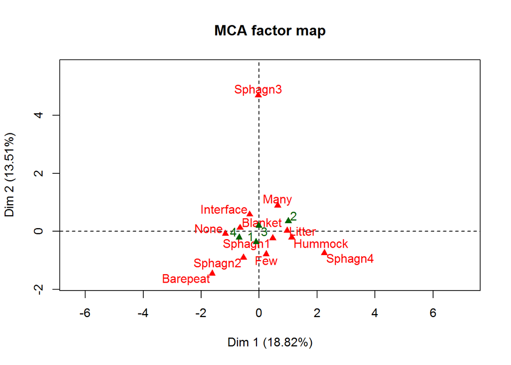

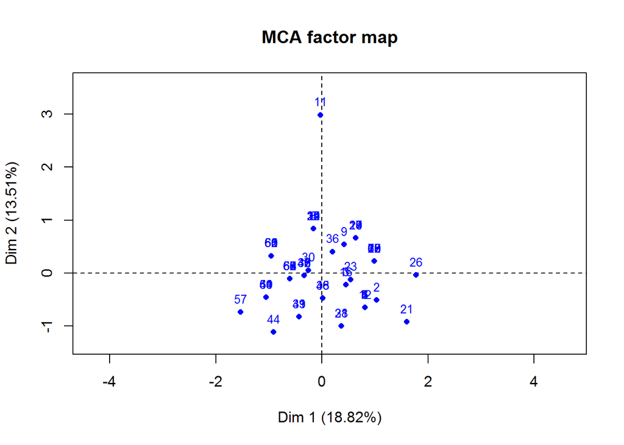

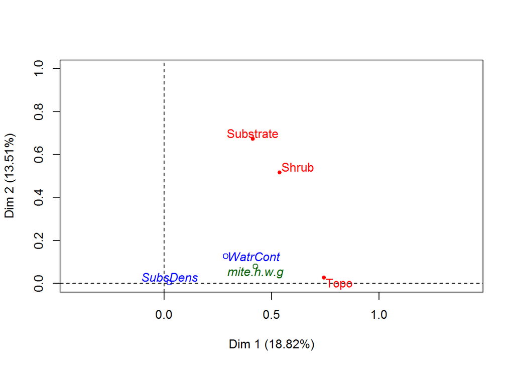

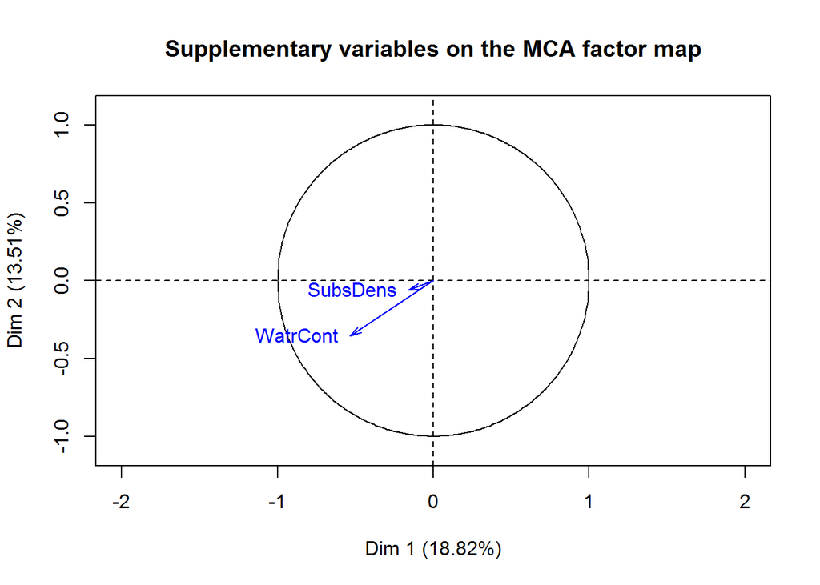

```r
mite.h <- decostand(mite, "hel") # 进行数据变换
mite.h.ward <- hclust(dist(mite.h), "ward.D2") # 对距离矩阵进行 ward 最小方差聚类分析
mite.h.w.g <- cutree(mite.h.ward, 4) # 将聚类结果分成 4 份
mite.envplus <- data.frame(mite.env, mite.h.w.g) # 整合数据框信息

# 对定性环境数据 + 补充变量进行多重对应分析
# (1) quantitative environmental data
# (2) 4-group mite classification
# 默认进行绘图展示: graph=TRUE.
mite.env.MCA <- MCA(mite.envplus,
                    quanti.sup = 1:2,
                    quali.sup = 6)
```

> **重点在于对结果的解读**

```r
mite.env.MCA
```

```
## **Results of the Multiple Correspondence Analysis (MCA)**
## The analysis was performed on 70 individuals, described by 6 variables
## *The results are available in the following objects:
##
##    name
## 1  "$eig"
## 2  "$var"
## 3  "$var$coord"
## 4  "$var$cos2"
## 5  "$var$contrib"
## 6  "$var$v.test"
## 7  "$ind"
## 8  "$ind$coord"
## 9  "$ind$cos2"
## 10 "$ind$contrib"
```

[output cut: 29 more lines]

```r
# 展示列联表 - 变量 "Shrub" & "Topo"
table(mite.env$Shrub, mite.env$Topo)
```

```
##
##        Blanket Hummock
##   Few       14      12
##   Many      11      14
##   None      19       0
```

## 5.5 主坐标分析(Principal Coordinate Analysis, PCoA)

### 5.5.1 简介

PCA 以及 CA 强加了对象之间保留的距离: PCA 的 Euclidean 距离(以及物种数据预转换后的其他几个距离)和 CA的χ2距离. 如果希望根据一些其他相异性测度对对象进行排序 – PCoA 首选方法. PCoA 提供了一系列对象的 Euclidean距离, 对象之间的关系由相异性测度由进行评估.

与 PCA 和 CA 一样, PCoA 产生一组正交轴, 其重要性由特征值测量. 由于 PCoA 基于关联矩阵, 因此它可以直接表示 **对象之间的关系(如果关联矩阵处于 Q模式)** 或 **变量之间的关系(如果关联矩阵处于 R模式)**. 如果预测变量, 变量可以使用相关性或加权平均值与排序轴相关联, 并在排序图上绘制. 在具有 Euclidean属性(第3.3节)的关联度量的情况下, PCoA 以 Euclidean 的方式表现. 但是如果使用的关联系数是 非Euclidean, 则 PCoA 可以通过产生 **除正数之外的几个负特征值以及零特征值** 来作出两者之间的反应. 对应于 **负特征值的轴** 的复杂性, 不能在实际排序轴上表示. 在大多数应用中, 这不会影响对象在几个第一主轴上的表示, **但如果最大负特征值的绝对值与第一个正特征值相同, 则可能导致问题.**

几种技术方法解决 负特征根问题: 1> 为对象之间的平方差异添加常数(Lingoes修正); 2> 为相异性度量添加常数; 3> 通过保持特征向量与其原始 Euclidean范数(向量长度= 1)而不是将每个特征向量除以其特征值的平方根, 可以避免复杂的轴(第七章-空间分析中有应用; 由于特征向量没有转化处理, 因此不能使用 PCoA 进行分析, 无法展示对象之间的原始距离).

分析包 adespatial 中的 dist.ldc() 函数可以检验 相异性系数是否为 欧式, 或者判断 平方根是否为 欧式.

PCOA 结果图的解读 – 相似相近原则: 对象在图上的距离的远近表示关联测度上的相似性.

分析包 vegan 中的 wcmdscale() 函数可以计算 加权的 PCOA, 该方法基于 cmdscale() 函数.

### 5.5.2 使用 vegan 分析包的 cmdscale() 函数对河流数据集进行主坐标分析(PCoA)

*投影处理*

```r
# 对鱼类物种数据集的百分差异相异矩阵进行主坐标分析(PCOA)
# vegdist() 对群落数据进行相异指数的计算
# https://www.rdocumentation.org/packages/vegan/versions/2.4-2/topics/vegdist
spe.bray <- vegdist(spe) # 默认方法 - bray
spe.b.pcoa <- cmdscale(spe.bray,
                       k = (nrow(spe) - 1),
                       eig = TRUE)
```

```r
# https://www.rdocumentation.org/packages/vegan/versions/2.4-2/topics/ordiplot
# 绘制排序图
ordiplot(scores(spe.b.pcoa, choices = c(1, 2)),
         type = "t",
         main = "PCoA with species weighted averages")
```

```
## species scores not available
```

```r
abline(h = 0,
       lty = 3) # 添加线
abline(v = 0,
       lty = 3)
# 添加物种的加权平均预测值 | 计算加权平均值用于排序配置或环境变量的物种得分
# https://www.rdocumentation.org/packages/vegan/versions/2.4-2/topics/wascores
spe.wa <- wascores(spe.b.pcoa$points[, 1:2], spe)
text(spe.wa,
     rownames(spe.wa),
     cex = 0.7,
     col = "red")
# 对环境变量进行事后预测检验 - posteriori projection
# envfit() https://www.rdocumentation.org/packages/vegan/versions/2.4-2/topics/envfit
# 将环境变量或因子拟合到排序结果上
# envfit() 寻找 环境变量中的向量或者因子平均值
# ? 点向量的投影与相应的环境变量具有最大的相关性, 这些因子表示因子水平的平均值
# envfit() 对 环境变量 进行 置换检验, 计算 变量的 p-value
(spe.b.pcoa.env <- envfit(spe.b.pcoa, env))
```

```
##
## ***VECTORS
##
##         Dim1     Dim2     r2 Pr(>r)
## dfs  0.99035  0.13862 0.7210  0.001 ***
## ele -0.99355 -0.11335 0.5659  0.001 ***
## slo -0.79277  0.60953 0.1078  0.144
## dis  0.99152 -0.12997 0.5324  0.001 ***
## pH  -0.24915 -0.96847 0.0480  0.523
## har  0.96140  0.27515 0.2769  0.021 *
## pho  0.26728  0.96362 0.6912  0.001 ***
## nit  0.68217  0.73119 0.6117  0.001 ***
## amm  0.24946  0.96839 0.7076  0.002 **
## oxy -0.54779 -0.83661 0.7639  0.001 ***
## bod  0.25236  0.96763 0.8561  0.001 ***
## ---
## Signif. codes:  0 '***' 0.001 '**' 0.01 '*' 0.05 '.' 0.1 ' ' 1
## Permutation: free
## Number of permutations: 999
```

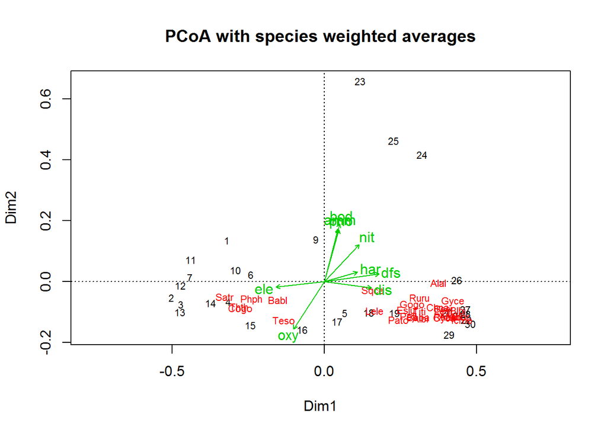

```r
# 绘制显著变量
plot(spe.b.pcoa.env,
     p.max = 0.05,
     col = 3)
```

### 5.5.3 使用 pcoa() 对河流数据集进行主坐标分析(PCoA)

还有另一种方法可进行 *双投影* (基于环境变量与 PCOA 排序轴的相关关系). 由 Euclidean 距离计算而来的 PCoA 产生了对应于在相同数据的 scaling-1 PCA 双序图中获得的特征向量.

分析包 ape 中可使用 pcoa() 和 biplot.pcoa() 函数.

```r
# https://www.rdocumentation.org/packages/ape/versions/5.3/topics/pcoa
# 使用 pcoa() 函数对物种向量进行主坐标分析和预测
(spe.h.pcoa <- pcoa(dist(spe.h)))
```

```
## $correction
## [1] "none" "1"
##
## $note
## [1] "There were no negative eigenvalues. No correction was applied"
##
## $values
##     Eigenvalues Relative_eig Broken_stick Cumul_eig Cumul_br_stick
## 1  7.2228938501 5.133437e-01  0.144128028 0.5133437      0.1441280
## 2  1.7987448715 1.278400e-01  0.107090991 0.6411837      0.2512190
## 3  1.2970422885 9.218307e-02  0.088572472 0.7333668      0.3397915
## 4  1.0780684157 7.662021e-02  0.076226793 0.8099870      0.4160183
## 5  0.6150272794 4.371107e-02  0.066967534 0.8536980      0.4829858
## 6  0.4691296076 3.334186e-02  0.059560127 0.8870399      0.5425459
## 7  0.4122804127 2.930149e-02  0.053387287 0.9163414      0.5959332
```

[output cut: 208 more lines]

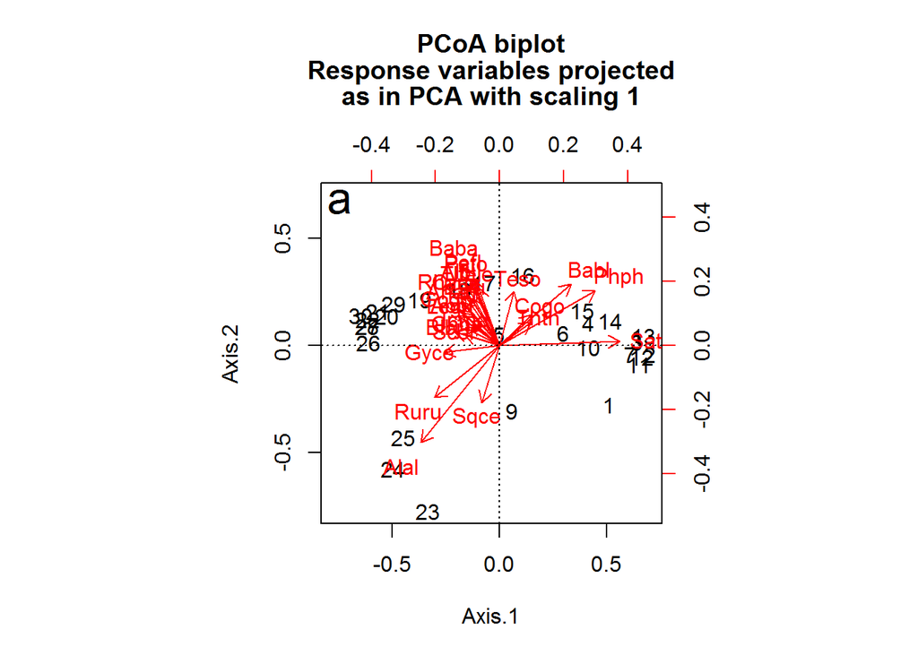

```r
# par(mfrow = c(1, 2))
# 第一个双序图: Hellinger-transformed species data
# https://www.rdocumentation.org/packages/ape/versions/5.3/topics/pcoa
# https://github.com/cran/ape/blob/master/R/biplot.pcoa.R
biplot.pcoa(spe.h.pcoa,
            spe.h,
            dir.axis1 = -1) # 反转轴1直接生成结果与 PCA 结果相当 - 相互比较; 排序轴的符号可任意
abline(h = 0, lty = 3)
abline(v = 0, lty = 3)
text(-0.5,
     0.45,
     "a",
     cex = 2)
```

- **为了将物种数据投影到 PCoA 图上, 使用具有与用于计算相异度矩阵变换相同的变换(如果有的话)的物种数据**

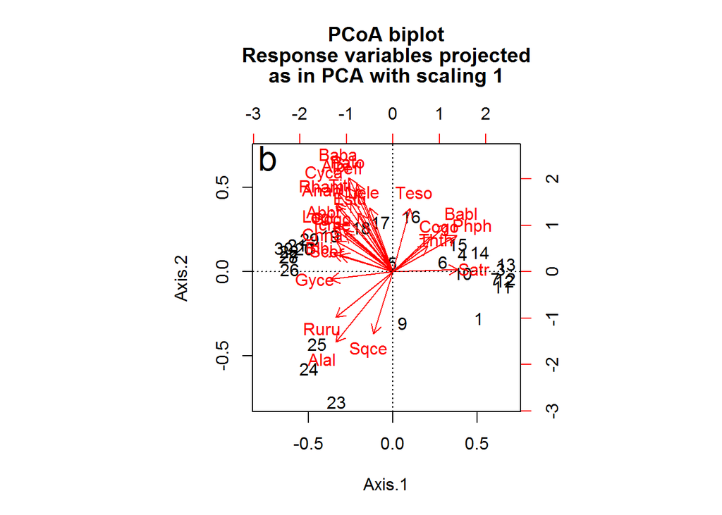

```r
# 第二个双序图: standardized Hellinger-transformed species data - 标准化
spe.std <- scale(spe.h)
biplot.pcoa(spe.h.pcoa,
            spe.std,
            dir.axis1 = -1)
abline(h = 0,
       lty = 3)
abline(v = 0,
       lty = 3)
text(-2.7,
     2.45, "b",
     cex = 2)
```

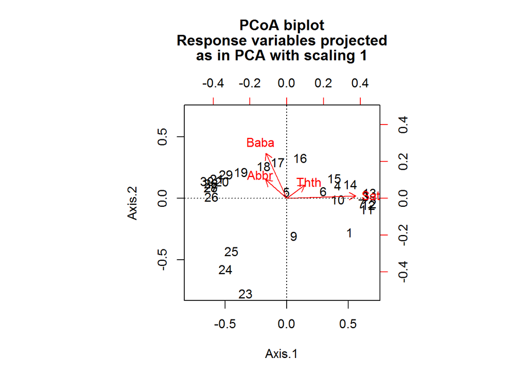

```r
# 第三个双序图: standardized Hellinger-transformed species data;
# 只绘制 4 个物种
spe.std <- scale(spe.h)
biplot.pcoa(spe.h.pcoa,
            spe.h[, c(2, 5, 11, 21)],
            dir.axis1 = -1)
abline(h = 0,
       lty = 3)
abline(v = 0,
       lty = 3)
```

对非欧式距离进行排序, 首选 PCoA; 分析包 ade4 在 Jaccard & Sørensen 相异性度量中计算了 相异度的平方根, 完全的欧式距离排序; 分析包 vegan 中使用 bray 方法进行百分量差异相异度计算, 其相异性度量可能不是欧式距离. 这种情况导致了一些 **负特征值**. 分析包 ape 中 pcoa() 函数可对其进行校正.

```r
# 比较 欧式(Euclidean)和非欧式相异矩阵的主坐标分析(PCOA)结果
# https://www.rdocumentation.org/packages/ade4/versions/1.7-13/topics/is.euclid
is.euclid(dist(spe.h)) # 检查距离矩阵是否是欧式的 - Euclidean
```

```
## [1] TRUE
```

```r
summary(spe.h.pcoa)
```

```
##            Length Class      Mode
## correction   2    -none-     character
## note         1    -none-     character
## values       5    data.frame list
## vectors    783    -none-     numeric
## trace        1    -none-     numeric
```

```r
spe.h.pcoa$values
```

```
##     Eigenvalues Relative_eig Broken_stick Cumul_eig Cumul_br_stick
## 1  7.2228938501 5.133437e-01  0.144128028 0.5133437      0.1441280
## 2  1.7987448715 1.278400e-01  0.107090991 0.6411837      0.2512190
## 3  1.2970422885 9.218307e-02  0.088572472 0.7333668      0.3397915
## 4  1.0780684157 7.662021e-02  0.076226793 0.8099870      0.4160183
## 5  0.6150272794 4.371107e-02  0.066967534 0.8536980      0.4829858
## 6  0.4691296076 3.334186e-02  0.059560127 0.8870399      0.5425459
## 7  0.4122804127 2.930149e-02  0.053387287 0.9163414      0.5959332
## 8  0.3236126046 2.299972e-02  0.048096282 0.9393411      0.6440295
## 9  0.1942121662 1.380300e-02  0.043466652 0.9531441      0.6874962
## 10 0.1685395834 1.197840e-02  0.039351426 0.9651225      0.7268476
## 11 0.1235468620 8.780692e-03  0.035647722 0.9739032      0.7624953
## 12 0.0835046563 5.934822e-03  0.032280719 0.9798380      0.7947760
## 13 0.0759645928 5.398937e-03  0.029194299 0.9852370      0.8239703
## 14 0.0513764625 3.651415e-03  0.026345296 0.9888884      0.8503156
## 15 0.0407307694 2.894807e-03  0.023699794 0.9917832      0.8740154
## 16 0.0313000342 2.224548e-03  0.021230658 0.9940077      0.8952461
## 17 0.0232647295 1.653465e-03  0.018915843 0.9956612      0.9141619
## 18 0.0151628431 1.077650e-03  0.016737194 0.9967389      0.9308991
## 19 0.0133146837 9.462979e-04  0.014679581 0.9976852      0.9455787
## 20 0.0103052835 7.324146e-04  0.012730263 0.9984176      0.9583090
## 21 0.0077422970 5.502586e-04  0.010878411 0.9989678      0.9691874
## 22 0.0063077278 4.483013e-04  0.009114743 0.9994161      0.9783021
## 23 0.0040023911 2.844570e-04  0.007431241 0.9997006      0.9857334
## 24 0.0021331293 1.516052e-04  0.005820935 0.9998522      0.9915543
## 25 0.0013971526 9.929809e-05  0.004277725 0.9999515      0.9958320
## 26 0.0004271756 3.036012e-05  0.002796244 0.9999819      0.9986283
## 27 0.0002552902 1.814392e-05  0.001371742 1.0000000      1.0000000
```

```r
# 对百分差异的相异矩阵进行主坐标分析(PCoA)
is.euclid(spe.bray)
```

```
## [1] FALSE
```

```r
spe.bray.pcoa <- pcoa(spe.bray)
spe.bray.pcoa$values # Observe eigenvalues 18 and following
```

```
##      Eigenvalues  Relative_eig Rel_corr_eig Broken_stick Cum_corr_eig
## 1   3.695331e+00  5.464785e-01 0.4332316505  0.144128028    0.4332317
## 2   1.098472e+00  1.624459e-01 0.1343469468  0.107090991    0.5675786
## 3   7.104740e-01  1.050674e-01 0.0896903953  0.088572472    0.6572690
## 4   4.149729e-01  6.136766e-02 0.0556797818  0.076226793    0.7129488
## 5   3.045604e-01  4.503947e-02 0.0429718837  0.066967534    0.7559207
## 6   1.917884e-01  2.836235e-02 0.0299924247  0.059560127    0.7859131
## 7   1.569703e-01  2.321333e-02 0.0259850463  0.053387287    0.8118981
## 8   1.319099e-01  1.950731e-02 0.0231007251  0.048096282    0.8349989
## 9   1.294251e-01  1.913984e-02 0.0228147364  0.043466652    0.8578136
## 10  8.667896e-02  1.281839e-02 0.0178948785  0.039351426    0.8757085
## 11  4.615780e-02  6.825978e-03 0.0132311063  0.035647722    0.8889396
## 12  3.864487e-02  5.714940e-03 0.0123664087  0.032280719    0.9013060
## 13  2.745800e-02  4.060586e-03 0.0110788585  0.029194299    0.9123848
## 14  1.306508e-02  1.932111e-03 0.0094223096  0.026345296    0.9218072
```

[output cut: 45 more lines]

```r
# 对百分差异的相异矩阵的平方根进行主坐标分析(PCoA)
is.euclid(sqrt(spe.bray))
```

```
## [1] TRUE
```

```r
spe.braysq.pcoa <- pcoa(sqrt(spe.bray))
spe.braysq.pcoa$values  # 观察特征值 - eigenvalues
```

```
##    Eigenvalues Relative_eig Broken_stick Cumul_eig Cumul_br_stick
## 1   3.21560824  0.354677497  0.140256109 0.3546775      0.1402561
## 2   1.03573822  0.114240607  0.104541823 0.4689181      0.2447979
## 3   0.80071738  0.088318107  0.086684680 0.5572362      0.3314826
## 4   0.54426205  0.060031412  0.074779918 0.6172676      0.4062625
## 5   0.44091188  0.048632019  0.065851347 0.6658996      0.4721139
## 6   0.38896013  0.042901808  0.058708489 0.7088015      0.5308224
## 7   0.33391888  0.036830827  0.052756109 0.7456323      0.5835785
## 8   0.29313251  0.032332143  0.047654068 0.7779644      0.6312325
## 9   0.25584733  0.028219635  0.043189782 0.8061841      0.6744223
## 10  0.23652013  0.026087869  0.039221528 0.8322719      0.7136439
## 11  0.19443183  0.021445584  0.035650099 0.8537175      0.7492940
## 12  0.18072725  0.019933986  0.032403346 0.8736515      0.7816973
## 13  0.15112925  0.016669364  0.029427156 0.8903209      0.8111245
## 14  0.12732111  0.014043356  0.026679903 0.9043642      0.8378044
## 15  0.10582112  0.011671935  0.024128883 0.9160361      0.8619332
## 16  0.09697075  0.010695751  0.021747930 0.9267319      0.8836812
## 17  0.08837033  0.009747135  0.019515787 0.9364790      0.9031970
## 18  0.07362981  0.008121274  0.017414947 0.9446003      0.9206119
## 19  0.07259890  0.008007567  0.015430820 0.9526079      0.9360427
## 20  0.06753369  0.007448880  0.013551121 0.9600568      0.9495938
## 21  0.06587845  0.007266309  0.011765406 0.9673231      0.9613593
## 22  0.05253221  0.005794236  0.010064726 0.9731173      0.9714240
## 23  0.05203557  0.005739458  0.008441350 0.9788568      0.9798653
## 24  0.04946184  0.005455578  0.006888555 0.9843123      0.9867539
## 25  0.04130873  0.004556300  0.005400459 0.9888686      0.9921543
## 26  0.03812350  0.004204973  0.003971888 0.9930736      0.9961262
## 27  0.03326408  0.003668986  0.002598262 0.9967426      0.9987245
## 28  0.02953257  0.003257404  0.001275510 1.0000000      1.0000000
```

```r
# 对百分差异的相异矩阵进行Lingoes校正-主坐标分析(PCoA)
spe.brayl.pcoa <- pcoa(spe.bray,
                       correction = "lingoes")
spe.brayl.pcoa$values # 观察特征值(eigenvalues) & col. 1 & col. 2
```

```
##      Eigenvalues    Corr_eig Rel_corr_eig Broken_stick Cum_corr_eig
## 1   3.695331e+00 3.764131306 0.4332316505  0.144128028    0.4332317
## 2   1.098472e+00 1.167272861 0.1343469468  0.107090991    0.5675786
## 3   7.104740e-01 0.779274609 0.0896903953  0.088572472    0.6572690
## 4   4.149729e-01 0.483773541 0.0556797818  0.076226793    0.7129488
## 5   3.045604e-01 0.373361024 0.0429718837  0.066967534    0.7559207
## 6   1.917884e-01 0.260589051 0.0299924247  0.059560127    0.7859131
## 7   1.569703e-01 0.225770961 0.0259850463  0.053387287    0.8118981
## 8   1.319099e-01 0.200710550 0.0231007251  0.048096282    0.8349989
## 9   1.294251e-01 0.198225738 0.0228147364  0.043466652    0.8578136
## 10  8.667896e-02 0.155479574 0.0178948785  0.039351426    0.8757085
## 11  4.615780e-02 0.114958410 0.0132311063  0.035647722    0.8889396
## 12  3.864487e-02 0.107445488 0.0123664087  0.032280719    0.9013060
## 13  2.745800e-02 0.096258614 0.0110788585  0.029194299    0.9123848
## 14  1.306508e-02 0.081865696 0.0094223096  0.026345296    0.9218072
```

[output cut: 45 more lines]

```r
# 对百分差异的相异矩阵进行cailliez校正-主坐标分析(PCoA)
spe.brayc.pcoa <- pcoa(spe.bray,
                       correction = "cailliez")
spe.brayc.pcoa$values # 观察特征值(eigenvalues) & col. 1 & col. 2
```

```
##      Eigenvalues   Corr_eig Rel_corr_eig Broken_stick Cum_corr_eig
## 1   3.695331e+00 5.20461437 0.4442681027  0.144128028    0.4442681
## 2   1.098472e+00 1.60465006 0.1369736134  0.107090991    0.5812417
## 3   7.104740e-01 1.09152082 0.0931726832  0.088572472    0.6744144
## 4   4.149729e-01 0.68985417 0.0588862466  0.076226793    0.7333006
## 5   3.045604e-01 0.52129425 0.0444978992  0.066967534    0.7777985
## 6   1.917884e-01 0.38710929 0.0330438139  0.059560127    0.8108424
## 7   1.569703e-01 0.36447367 0.0311116277  0.053387287    0.8419540
## 8   1.319099e-01 0.29671255 0.0253275095  0.048096282    0.8672815
## 9   1.294251e-01 0.27559544 0.0235249448  0.043466652    0.8908064
## 10  8.667896e-02 0.21600584 0.0184383509  0.039351426    0.9092448
## 11  4.615780e-02 0.15419396 0.0131620626  0.035647722    0.9224069
## 12  3.864487e-02 0.15378333 0.0131270104  0.032280719    0.9355339
## 13  2.745800e-02 0.11812808 0.0100834637  0.029194299    0.9456173
## 14  1.306508e-02 0.08848541 0.0075531526  0.026345296    0.9531705
```

[output cut: 45 more lines]

## 5.6 非度量多维尺度分析(Nonmetric Multidimensional Scaling, NMDS)

### 5.6.1 简介

如果排序图中的对象之间的确切的差异不是研究重点, 而是想探究排序关系在 小的 & 制定数量的 轴中 对象之间的相互关系, 非度量多维尺度分析(Nonmetric Multidimensional Scaling, NMDS) 可能会是较好的解决方案. 与 PCoA 一样, NMDS 可以从任何相异性矩中 生成对象的坐标(或者说是进行排序分析). *该方法可以处理缺失值, 只要有足够的度量来相对于其他几个对象定位每个对象.* **NMDS 不是 特征值分析方法**, 并且它不会最大化与排序的各个轴相关的可变性. 结果, 曲线可以任意旋转或反转。

分析过程如下:

- 指定排序的轴(尺寸)的所需数量 m ;
- 构造 m 维中对象的初始配置, 以用作迭代调整过程的起点. 这是一个棘手的步骤, 因为最终结果可能取决于启动配置. PCoA 排序可能是一个很好的起点. 否则, 尝试使用**随机**初始配置的**许多独立运行**;
- **迭代过程**尝试将对象定位在所请求的维数中(对象的位置), 以便最小化应力函数(stress function, 从0到1缩放), 该度量函数测量还原空间配置中的不相似性从单调到单调的程度. 关联矩阵中的原始差异; (**???**)
- 不断调整位置, 直到压力值(stress value)不能降低, 或直到达到预定的低值(容忍缺乏配合)
- 大多数 NMDS 程序使用 PCA 作为最终解决方案, 以便于结果的解释

使用分析包 vegan 中的 metaMDS() 函数进行非度量多维尺度分析(Nonmetric Multidimensional Scaling, NMDS); 使用 wascores() 函数也可以将物种信息添加到排序结果图中; 解释性变量可以通过 envfit() 函数进行添加.

```r
# https://www.rdocumentation.org/packages/vegan/versions/2.4-2/topics/metaMDS
# 对鱼类数据集的百分比差异相异矩阵进行非度量多维尺度分析(NMDS)
(spe.nmds <- metaMDS(spe,
                    distance = "bray"))
```

```
## *** Solution reached
```

```
##
## Call:
## metaMDS(comm = spe, distance = "bray")
##
## global Multidimensional Scaling using monoMDS
##
## Data:     spe
## Distance: bray
##
## Dimensions: 2
## Stress:     0.07376315
## Stress type 1, weak ties
## Two convergent solutions found after 20 tries
## Scaling: centring, PC rotation, halfchange scaling
## Species: expanded scores based on 'spe'
```

```r
spe.nmds$stress
```

```
## [1] 0.07376315
```

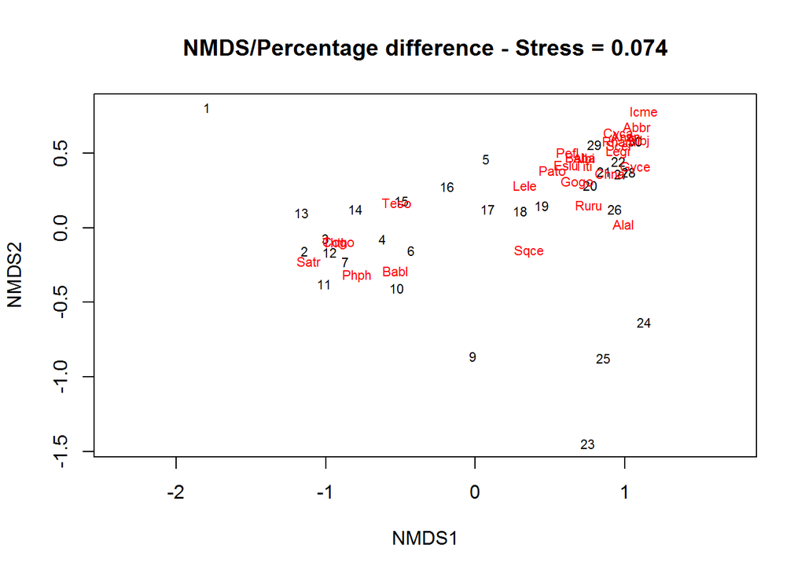

```r
plot(
  spe.nmds,
  type = "t",
  main = paste(
    "NMDS/Percentage difference - Stress =",
    round(spe.nmds$stress, 3)
    )
  )
```

- **注意比较分析 NMDS & PCA & CA & PCoA 之间的异同**

如果相异性矩阵中含有缺失值, 使用 isoMDS() 函数进行 NMDS 分析. 默认情况下, isoMDS() 函数会调用 cmdscale() 函数的 PCoA 分析进行初始配置. 为避免获得局部最小值, 建议使用分析包 labdsv 中的 bestnmds() 进行分析(该函数是 isoMDS 的一个包装器, 通过随机初始值进行分析; 该函数保留了最小应力值的解)

通过 Shepard diagram 对 NMDS 分析结果图进行比较 – 排序图中对象之间的相异性 与 原始相异性; 排序结果的优劣程度通过线性或者非线性回归的 R方 进行评估. 使用分析包 vegan 中的 stressplot() & goodness() 都可获得相应评估参数.

- https://www.displayr.com/goodness-of-fit-in-mds-and-t-sne-with-shepard-diagrams/
- http://www.analytictech.com/borgatti/mds.htm
- https://rdrr.io/cran/vegan/man/goodness.metaMDS.html
- https://rdrr.io/github/vmikk/metagMisc/man/shepard_plot.html

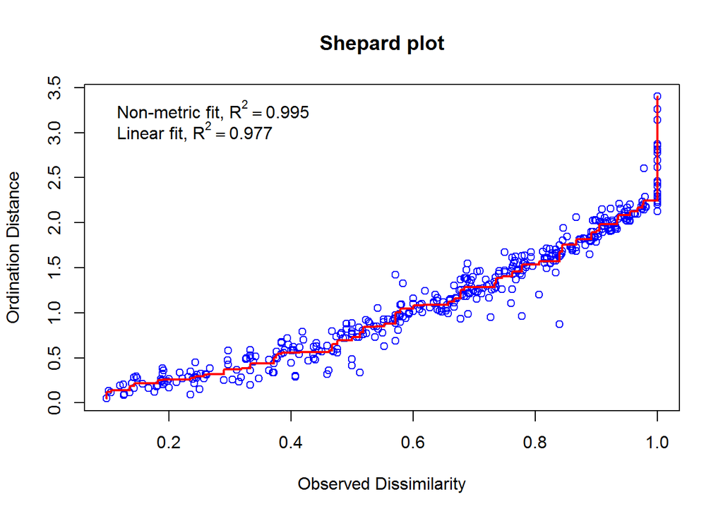

```r
# par(mfrow = c(1, 2))
# stressplot() https://www.rdocumentation.org/packages/vegan/versions/2.4-2/topics/stressplot.wcmdscale
# https://www.rdocumentation.org/packages/vegan/versions/2.4-2/topics/goodness.metaMDS
stressplot(spe.nmds,
           main = "Shepard plot")
```

```r
(gof <- goodness(spe.nmds))
```

```
##  [1] 0.020088056 0.009078174 0.012551833 0.012583526 0.021922879
##  [6] 0.014337297 0.009983703 0.027327780 0.011501826 0.018599029
## [11] 0.010454480 0.013516997 0.015365460 0.012413669 0.009730373
## [16] 0.015711632 0.013045157 0.010752382 0.006875454 0.006956005
## [21] 0.007834157 0.016694420 0.010339200 0.021675435 0.006135716
## [26] 0.005745334 0.007220785 0.011961540 0.006358984
```

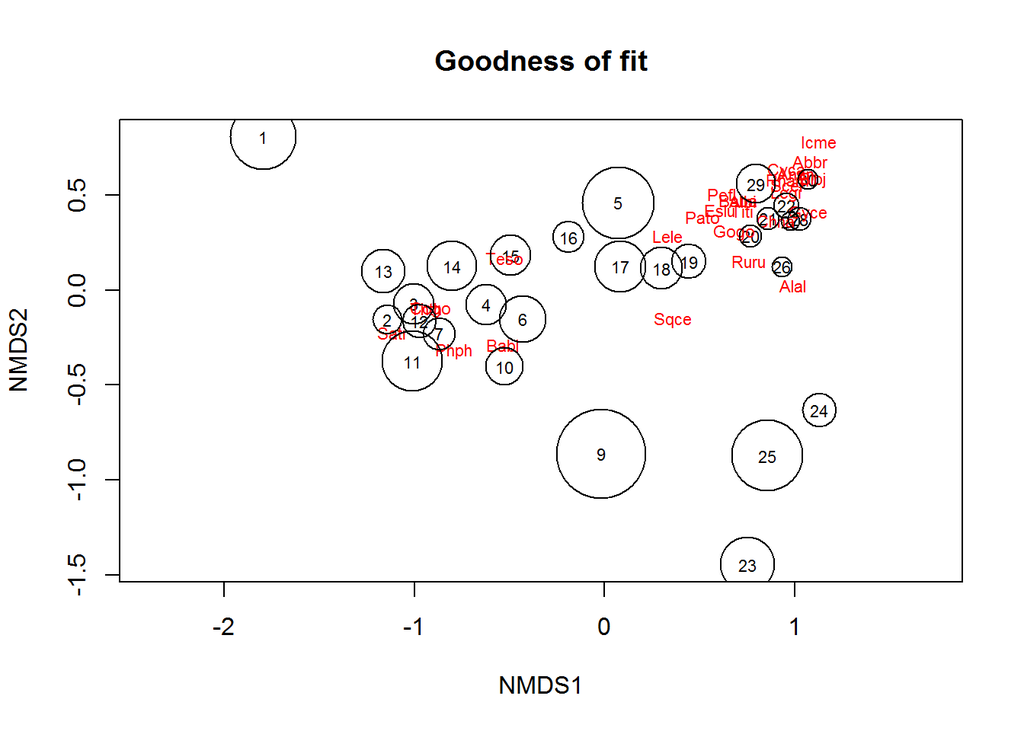

```r
plot(spe.nmds,
     type = "t",
     main = "Goodness of fit")
points(spe.nmds,
       display = "sites",
       cex = gof * 300)
```

与其他的排序方法一样, NMDS 排序图中可以添加聚类结果的信息(根据分组通过颜色进行区分).

```r
# 对百分比相异矩阵进行 Ward 最小方差聚类分析, 并划分出 4 组
spe.bray.ward <- hclust(spe.bray,
                        "ward.D")
spe.bw.groups <- cutree(spe.bray.ward,
                        k = 4)
grp.lev <- levels(factor(spe.bw.groups)) # 反馈因子的不同值 - 向量形式
# 结合汇总非度量多维尺度分析结果
sit.sc <- scores(spe.nmds) # 两列多行的'矩阵'类型
# 绘制排序结果图 - x-y 绘图
p <- ordiplot(sit.sc,
              type = "n",
              main = "NMDS/% difference + clusters Ward/% difference")
```

```
## species scores not available
```

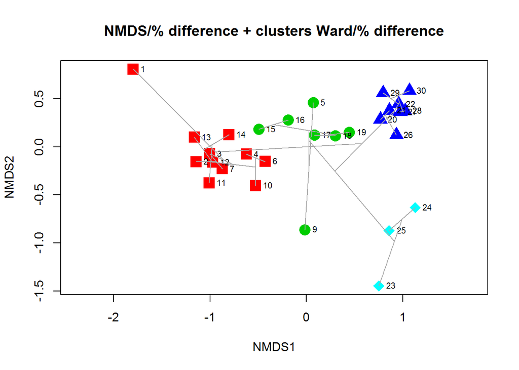

```r
for (i in 1:length(grp.lev)) {
  points(sit.sc[spe.bw.groups == i, ],
         pch = (14 + i),
         cex = 2,
         col = i + 1)
  }
text(sit.sc,
     row.names(spe),
     pos = 4,
     cex = 0.7)
# 添加树形图
ordicluster(p,
            spe.bray.ward,
            col = "dark grey")
```

### 5.6.3 如何选择主坐标分析与非度量多维尺度分析? PCoA or NMDS ?

两种方法具有相类似的目标: 获得小数量轴(2~3)上的对象的有意义的排序结果. PCoA 通过对已变换数据的相异性矩阵进行奇异值分解(eigen-decomposition)来分析, NMDS 通过迭代优化算法进行分析. 两种方法的孰优孰劣尚无明确的评判. 两种方法在所有的情景下, 产生的效用是否相同, 最后获得的解决方案是否一致? 如何比较分析两种方法的基本规则和应用?

> **NMDS**
- 迭代算法可以根据计算的起始点找到不同的解决方案, 在大多数情况下, 计算的起始点是随机选择的配置;
- 在NMDS计算过程中, 相异性会被扭曲(拉伸或挤压) – 方法的公认属性; 排序方案中的距离并不真正对应起始的相异性;
- NMDS 的第一轴不一定能最大化观测值的方差. 大多数(如果不是全部) NMDS 程序计算 NMDS 结果的 PCA 旋转, 以便第一轴最大化 NMDS 解决方案的方差
- 同的NMDS功能可以使用不同的标准来最小化压力. 解决方案可能根据一个(或R函数)选择优化的标准而不同;
- R函数可能包含可能影响解决方案的其他几个参数. 除了经验丰富的用户之外, 很难确定哪种选项组合最适合特定数据集;
- 用户必须设置k, 排序解决方案的维数. 可以产生所有的排序轴,即min [p，n 1], 但是由于距离是扭曲的, 所以解决方案不精确. 建议设置k <（n’1）
- 压力统计量不表示在排序解决方案中表示的数据的方差的比例。 相反, 它表示原始相异性的变形量, 这是非常不同的。

应用于生态分析 – 当有必要将 3~4 维度的数据挤出 PCA or PCoA 分析中的二维时, NMDS 可以很好地表示二维中各位点之间主要的相异性关系. 在这种情况下, 最好是使用 PCA 或 PCoA 排序轴作为 NMDS 的输入, 以确保 NMDS 解决方案不会明显偏离度量排序.

> **PCoA**
- 通过奇异值分解寻找最优的解决方案 - PCoA 具有独特性;
- 在排序分析过程中, 相异性不会被扭曲;
- 通常根据相异性矩阵获取第一排序轴(方差最大化的轴);
- 产生给定相异性矩阵的所有排序轴, 排序结果准确;
- 通过 PCoA 的全部矩阵可以重建出对象的距离. 由 PCoA 计算而来的对象之间的欧式距离的矩阵 与 PCoA 的相异性矩阵严格相等.
- 可重复性强.
- 可计算 pseudo-R方 统计值 – 感兴趣轴的特征值之和 除以 所有的特征值之和.

应用于生态分析 – 1> PCoA 对降维的二维或三维空间中的对象进行排序分析, 2> PCoA 还可以在计算适当选择的不同度量后充当数据转换. 全维度 PCoA 空间中的对象坐标表示转换后的数据. PCoA 可以作为很多分析过程的起点, 比如 db-RDA & k-means 划分聚类等. **PCoA 可以再很多分析中使用**

## 5.7 手写主成分分析(PCA) 排序函数

计算过程:

- 1 - 计算原始或已中心化数据矩阵的协方差矩阵 S .
- 2 - 计算 S 的特征向量和特征值
- 3 - 提取特征向量的矩阵 U 并计算用于 scaling-1 双序图的主要成分的矩阵 F. 此步骤涉及已中心化的数据
- 4 - 计算矩阵 U2 和 G 用于 scaling-2 双序图
- 5 - 输出结果

```r
myPCA <- function(Y) {
  Y.mat <- as.matrix(Y)
  object.names <- rownames(Y)
  var.names <- colnames(Y)

  # 质心化数据 ? - Centre the data (needed to compute matrix F)
  Y.cent <- scale(Y.mat,
                  center = TRUE,
                  scale = FALSE) # 是否对数据进行缩放 | F - 否

  # 计算协方差 - 矩阵 S
  Y.cov <- cov(Y.cent)

  # 特征向量 & 特征值 - Eigenvectors and eigenvalues of S (eq. 9.1 & 9.2)
  Y.eig <- eigen(Y.cov)

  # 复制特征向量至矩阵 U (用于表征变量 - scaling 1 - biplots)
  U <- Y.eig$vectors
  rownames(U) <- var.names

  # 计算矩阵 F (用以表征对象 - scaling 1 - plots)
  F <- Y.cent %*% U  # eq. 9.4
  rownames(F) <- object.names

  # 计算矩阵 U2 (用以表征变量 - scaling 2 plots)
  U2 <- U %*% diag(Y.eig$values ^ 0.5)
  rownames(U2) <- var.names

  # 计算矩阵 G (用以表征对象 - scaling 2 plots)
  G <- F %*% diag(Y.eig$values ^ 0.5)
  rownames(G) <- object.names

  # 输出包含结果的所有列表
  result <- list(Y.eig$values, U, F, U2, G)
  names(result) <- c("eigenvalues", "U", "F", "U2", "G")
  result
}

# 使用手写 PCA-函数对鱼类物种数据集进行分析
fish.PCA <- myPCA(spe.h)
summary(fish.PCA)
```

```
##             Length Class  Mode
## eigenvalues  27    -none- numeric
## U           729    -none- numeric
## F           783    -none- numeric
## U2          729    -none- numeric
## G           783    -none- numeric
```

```r
# 特征值
fish.PCA$eigenvalues
```

```
##  [1] 2.579605e-01 6.424089e-02 4.632294e-02 3.850244e-02 2.196526e-02
##  [6] 1.675463e-02 1.472430e-02 1.155759e-02 6.936149e-03 6.019271e-03
## [11] 4.412388e-03 2.982309e-03 2.713021e-03 1.834874e-03 1.454670e-03
## [16] 1.117858e-03 8.308832e-04 5.415301e-04 4.755244e-04 3.680458e-04
## [21] 2.765106e-04 2.252760e-04 1.429425e-04 7.618319e-05 4.989831e-05
## [26] 1.525627e-05 9.117507e-06
```

```r
# 特征值表示为百分比
(pv <-round(100 * fish.PCA$eigenvalues / sum(fish.PCA$eigenvalues),
  2))
```

```
##  [1] 51.33 12.78  9.22  7.66  4.37  3.33  2.93  2.30  1.38  1.20  0.88
## [12]  0.59  0.54  0.37  0.29  0.22  0.17  0.11  0.09  0.07  0.06  0.04
## [23]  0.03  0.02  0.01  0.00  0.00
```

```r
# 总方差(分母)的替代计算, 两位小数
round(100 * fish.PCA$eigenvalues / sum(diag(cov(spe.h))),
      2)
```

```
##  [1] 51.33 12.78  9.22  7.66  4.37  3.33  2.93  2.30  1.38  1.20  0.88
## [12]  0.59  0.54  0.37  0.29  0.22  0.17  0.11  0.09  0.07  0.06  0.04
## [23]  0.03  0.02  0.01  0.00  0.00
```

```r
# 将累积特征值表示为百分比, 两位小数
round(cumsum(100 * fish.PCA$eigenvalues / sum(fish.PCA$eigenvalues)),
      2)
```

```
##  [1]  51.33  64.12  73.34  81.00  85.37  88.70  91.63  93.93  95.31  96.51
## [11]  97.39  97.98  98.52  98.89  99.18  99.40  99.57  99.67  99.77  99.84
## [21]  99.90  99.94  99.97  99.99 100.00 100.00 100.00
```

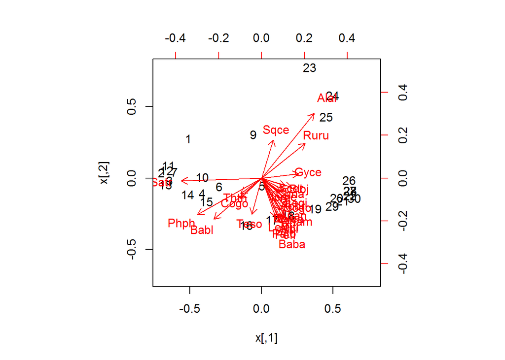

```r
# 绘制双序图
# par(mfrow = c(1, 2))
# scaling 1 -- distance biplot
biplot(fish.PCA$F, fish.PCA$U)
```

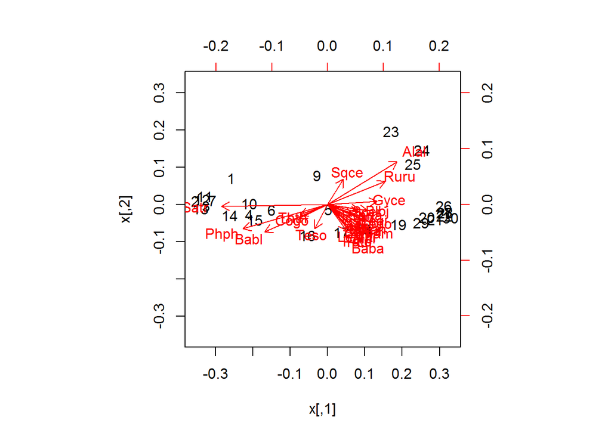

```r
# scaling 2 -- correlation biplot
biplot(fish.PCA$G, fish.PCA$U2)
```

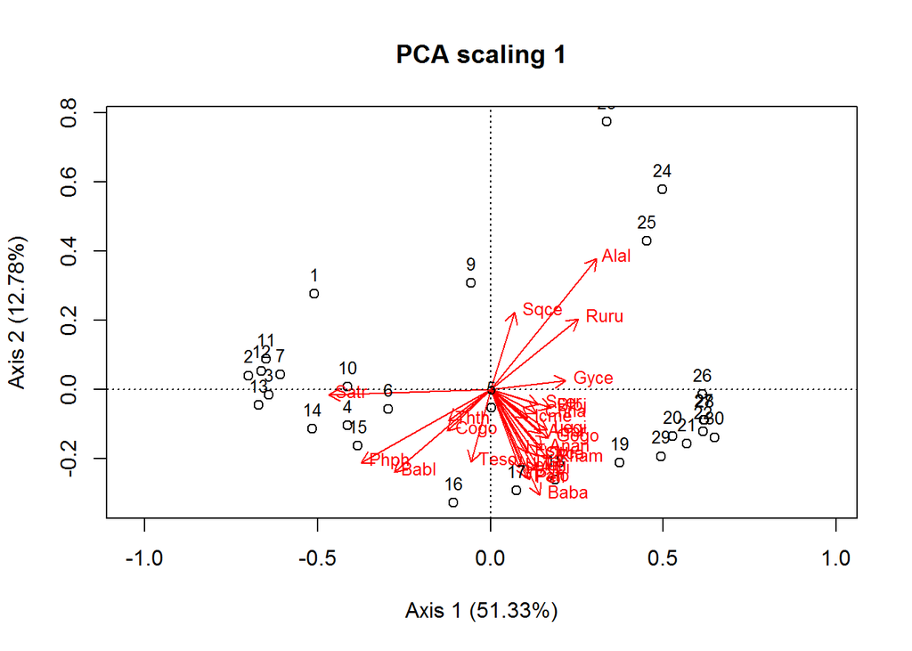

```r
# 使用基本函数 plot() 进行绘制
# par(mfrow = c(1, 2))
# scaling 1 -- distance biplot
plot(
  fish.PCA$F[, 1],
  fish.PCA$F[, 2],
  asp = 1,
  main = "PCA scaling 1",
  xlab = paste("Axis 1 (", pv[1], "%)", sep = ""),
  ylab = paste("Axis 2 (", pv[2], "%)", sep = "")
  )
# 绘制变量
arrows(
  x0 = 0,
  y0 = 0,
  fish.PCA$U[, 1],
  fish.PCA$U[, 2],
  length = 0.1,
  col = "red"
  )
# 添加对象
text(
  fish.PCA$F[, 1],
  fish.PCA$F[, 2],
  labels = row.names(spe),
  pos = 3,
  cex = 0.8
  )
# 添加变量名
text(
  fish.PCA$U[, 1],
  fish.PCA$U[, 2],
  labels = colnames(spe),
  adj = c(-0.2, 0.2),
  col = "red",
  cex = 0.8
  )
abline(h = 0,
       lty = 3)
abline(v = 0,
       lty = 3)
```

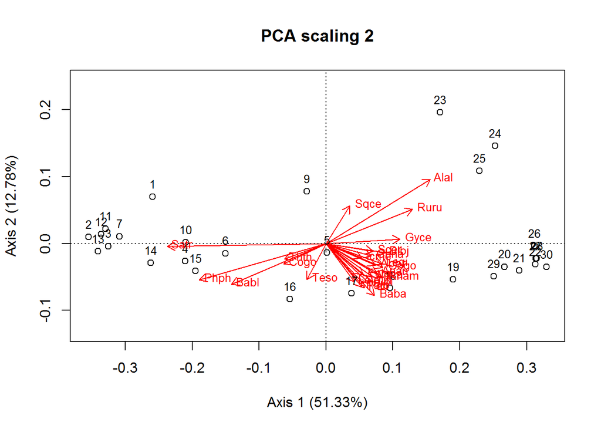

```r
# scaling 2 -- correlation biplot
plot(
  fish.PCA$G[, 1],
  fish.PCA$G[, 2],
  asp = 1,
  main = "PCA scaling 2",
  xlab = paste("Axis 1 (", pv[1], "%)", sep = ""),
  ylab = paste("Axis 2 (", pv[2], "%)", sep = "")
  )
# 绘制变量
arrows(
  x0 = 0,
  y0 = 0,
  fish.PCA$U2[, 1],
  fish.PCA$U2[, 2],
  length = 0.1,
  col = "red"
  )
# 添加对象
text(
  fish.PCA$G[, 1],
  fish.PCA$G[, 2],
  labels = row.names(spe),
  pos = 3,
  cex = 0.8
  )
# 添加变量名
text(
  fish.PCA$U2[, 1],
  fish.PCA$U2[, 2],
  labels = colnames(spe),
  col = "red",
  adj = c(-0.2, 0.2),
  cex = 0.8
  )
abline(h = 0, lty = 3)
abline(v = 0, lty = 3)
```